# La Corrupción en América Latina

Repositorio GitHub: https://github.com/LuciaLlatas/Trabajo-GrupoR-LlatasLucia-20193345-Zapata-MariaLuz-20183247-.git

```r
library(rmdformats)
library(jmv)
library(ggplot2)
library(psych)
library(DescTools)
library(plotrix)
library(moments)
```

```r
library(rio)
data=import("https://github.com/LuciaLlatas/Trabajo-GrupoR-LlatasLucia-20193345-Zapata-MariaLuz-20183247-/raw/5910f1625629113f99a928cfe81ace13d1cc741f/final_data.RDS")
names(data)
```

```
##  [1] "country"       "CPI"           "year"          "gdp_pc"
##  [5] "gini"          "govt_spending" "poverty_rate"  "bur_rem"
##  [9] "pcf"           "prop_rights"   "infra_spend"   "log_gdp"
```

# **I. Análisis teórico**

## **Revisión de la literatura**

- La corrupción es un problema que ha socavado a los gobiernos y administraciones públicas en América Latina. El informe presentado por el Programa para el Desarrollo de Naciones Unidas (PNUD) en 2002 afirma que los países iberoamericanos presentan algunos de los índices de corrupción más altos del mundo. Asimismo, indica que la corrupción es uno de los principales impedimentos para el desarrollo regional y que ésta se ha multiplicado en los últimos años (Bautista, Oscar 2012:49) Ante los escándalos de corrupción y la percepción del fenómeno, las distintas sociedades latinoamericanas están exigiendo respuestas institucionales sólidas, así como una respuesta adecuada por parte del sistema de justicia. Así, se han tratado de mejorar los marcos legales e institucionales, y la mayoría de los países se han juntado y cooperado a iniciativas internacionales, mediante la creación de agencias anticorrupción, introducir leyes procesales y normas administrativas y se han dado pasos importantes en modo de transparencia y acceso a la información pública, entre otros compromisos. Además, como han puesto sobre la mesa el caso Odebrecht y sus ramificaciones, la lucha contra la corrupción no es responsabilidad única de cada país: Es un problema a nivel regional y global, no solo porque daña a muchos países, sino que con frecuencia es necesario, la colaboración o apoyo de otros países para realizar una persecución adecuada. Se requiere de más especialización y capacidad de las agencias contra la corrupción, una mayor colaboración interinstitucional, más intercambio de información a nivel global y mejores formas para proteger a los denunciantes. Al respecto, frente a los factores que incitan a la corrupción como el soborno en todas sus formas, falta de instituciones eficaces, responsables y transparentes en todos los niveles, no existe una garantía del acceso público a la información de conformidad con las leyes nacionales y los acuerdos globales. Entonces, la Agenda 2030 sitúa como uno de sus 17 Objetivos de Desarrollo Sostenible (ODS) el combate a la corrupción, vinculando la construcción de instituciones democráticas sólidas con la lucha contra esta lacra. Así, en las metas del ODS 16 se prevé “reducir sustancialmente la corrupción, garantizar mejores instituciones de alto nivel y la eficacia como acceso a las leyes” (Ramos y Álvarez 2019: 23). Asimismo, la acción por parte de los Estado, en el año 2018, establecieron como objetivo de gobierno dedicado a la “Gobernabilidad Democrática frente a la Corrupción”, el cual fue firmado por 34 países por la Cumbre de las Américas, la cual es un hito y la expresión más reciente de la voluntad política para la gobernabilidad democrática y la lucha contra la corrupción. En octubre de ese mismo año, durante la junta de Alto Nivel del Programa Regional de la OCDE para América Latina y el Caribe sobre Integridad para el Buen Gobierno, se discutió y planteó de manera conjunta un plan de acción para poder materializar el compromiso de los países. Este plan propone 103 medidas que los gobiernos de la región pueden emprender para avanzar hacia la erradicación de la corrupción en las administraciones públicas y garantizar una política más inclusiva (2019: 4).

## **Factores relacionados a la corrupción**

- La identificación de factores que permitan a los Estados explicar y combatir la corrupción en sus gobiernos es una tarea importante desde el ámbito académico. En el presente trabajo, recopilamos siete factores que consideramos explican un determinado nivel de corrupción en la región latinoamericana.El primer factor es el Producto Interno Bruto per cápita, este nos permite comparar las diferencias en cuanto a condiciones económicas entre los habitantes de los países latinoamericanos.Con respecto a su relación con la corrupción, creemos que si el PIB per cápita es alto (lo que indicaría un nivel de adquisión economica alto en los habitantes) el nivel de corrupción será bajo pues el bienestar económico sería un desincentivo a las acciones deshonestas desde el gobierno.El segundo factor sería la Tasa de Pobreza pues las personas pobres necesitan acceso a los servicios que ofrece el gobierno, por lo que un nivel más alto de pobreza significa que más ciudadanos podrían estar dispuestos a pagar sobornos para acceder a estos servicios (Juresten y Bjornskov 2014). En tercer lugar, es el nivel de desigualdad en los países latinoamericanos. Según You y Khagram (2005), cuando el nivel de desigualdad es alto se esperarían niveles más altos de corrupción ya que la población de ricos, podrían usar su poder económico para coaccionar y realizar prácticas corruptas que les hagan mantener sus posiciones actuales y/o beneficiarse de ciertas políticas que respondan directamente a sus intereses. Otro factor a considerar son los Derechos de propiedad. Según Dimant y Tosato, la poco efectividad de los Estados para garantizar la aplicación de los contratos y los derechos de propiedad, incita a las personas del sector privado a participar en comportamientos corruptos para hacer preservar estos derechos (2018: 341) El factor de la Remuneración burocrática, el cual hace referencia a los salarios de los servicodres públicos, se relaciona con la corrupción pues se esperaría que burocrátas con salarios altos tendrían menos incentivos para caer en actos corrupctos.  
  Asimismo, un estudio de Goel y Nelson en 1998 demostró que el tamaño del gobierno, particularmente el gasto público de este tiene una gran influencia para incrementar la corrupción. Aunque algunos estudios superiores contradecían esta tesis, es importante considerar el estudio de Kotera y otros autores (2012) que demostró que ante niveles bajos de democracia, el tamañaño del gasto estatal aumentaría la corrupción. Este estudio podría ser particularmente infkuyente en nuetsro trabajo puesto que las democracias en America Latina son relativamente nuevas y presentan diferentes elementos que demuestran su debilidad, la corrupción es uno de ellos. En general, esperariamos que a mayor gasto publico, el nivel de corrupción se eleve. El ultimo factor a considerar sería el financiamiento de campañas públicas. El no financiamiento de campañas por parte del Estado que implica una asignación de presupiesto y rendicion de cuentas por parte d elos partidos políticos, es una oportunidad común para la corrupción desde el ambito privado al público. Podríamos recordar el escandalo de corrupción desatado a partir de la publicación de redes de sobornos y financiamiento de campañas en las eleccciones presidenciales de paises como Perú, Argentina, Colombia y otros países de la región por parte de la empresa multinacional Odrebrecht. Es así que se espera que los países con niveles más altos de financiamiento de campañas públicas tuvieran niveles más bajos de corrupción.

## **Objetivos**

- El ojetivo general de nuestro trabajo es determinar los principales factores que explican un nivel alto de corrupción en América Latina. Ello se realizará a partir de los siete factores que hemos identificado tienen una gran relación con la corrupción previamente. De igual manera, los objetivos específicos de este reporte son dos. En primer lugar, elegir el modelo estadístico más adecuado para lograr el objetivo general. En segundo lugar, buscamos conocer si nuestro estudio nos permite identificar soluciones de políticas públicas para reducir el nivel de corrupción a partir de la identificación de los principales causales de corrupción en la región.

## **Pregunta de investigación**

- La pregunta de investigación para nuestro trabajo es la siguiente: ¿Cuáles son los principales factores que determinan un alto nivel de corrupción en los países de América Latina?

## **Hipótesis**

- La hipotesis que responde a nuestra pregunta es que el nivel de corrupción en los países de América Latina, está determinado principalmente por el nivel de pobreza y desigualdad en esta región.

# **II. Analisis descriptivo**

- Selección de datos del año 2018

```r
data=subset(data, year== 2018)
str(data)
```

```
## tibble [22 x 12] (S3: tbl_df/tbl/data.frame)
##  $ country      : chr [1:22] "Uruguay" "Chile" "Costa Rica" "Cuba" ...
##  $ CPI          : num [1:22] 70 67 56 47 43 40 37 37 36 35 ...
##  $ year         : num [1:22] 2018 2018 2018 2018 2018 ...
##  $ gdp_pc       : num [1:22] 17278 15925 12112 8822 6004 ...
##  $ gini         : num [1:22] 39.7 NA 48 NA NA 41.4 NA 49.2 50.4 53.9 ...
##  $ govt_spending: num [1:22] 35 22.4 29.8 NA NA ...
##  $ poverty_rate : num [1:22] 0.1 NA 1.5 NA NA 1.3 NA 1.7 4.2 4.4 ...
##  $ bur_rem      : num [1:22] 3.92 3.48 3.46 3.83 3.57 ...
##  $ pcf          : num [1:22] 3.693 3.007 3.4 2.617 0.279 ...
##  $ prop_rights  : num [1:22] 0.838 0.872 0.862 0.291 0.794 0.868 0.796 0.688 0.57 0.832 ...
##  $ infra_spend  : num [1:22] NA NA NA NA NA ...
##  $ log_gdp      : num [1:22] 4.24 4.2 4.08 3.95 3.78 ...
```

- Para nuestra investigación es necesario definir y analizar las variables independientes que nos ayudarán a conocer los principales factores que determinarían un nivel alto de corrupción en los países de America Latina. En primer lugar, nuestra variable dependiente será el Índice de Percepción de Corrupción (CPI) que será convertida a una variable ordinal con los niveles bajo, intermedio y alto de corrupción. Las variables independientes serán el PBI per Cápita (gdp_pc), el Coeficiente de Desigualdad (gini), Gasto Público (govt_spending), Tasa de Pobeza (poverty_rate), Remuneración Burocrática (bur_rem), Financiamiento de campañas públicas (pcf) y Derechos de propiedad (prop_rights).

## **Análisis Descriptivo de la variable dependiente**

### Índice de Percepción de la Corrupción

```r
descriptives(data,vars=vars(CPI),freq = TRUE)
```

```
##
##  DESCRIPTIVES
##
##  Descriptives
##  ----------------------------------
##                          CPI
##  ----------------------------------
##    N                           22
##    Missing                      0
##    Mean                  36.68182
##    Median                35.00000
##    Standard deviation    13.32876
##    Minimum               18.00000
##    Maximum               70.00000
##  ----------------------------------
```

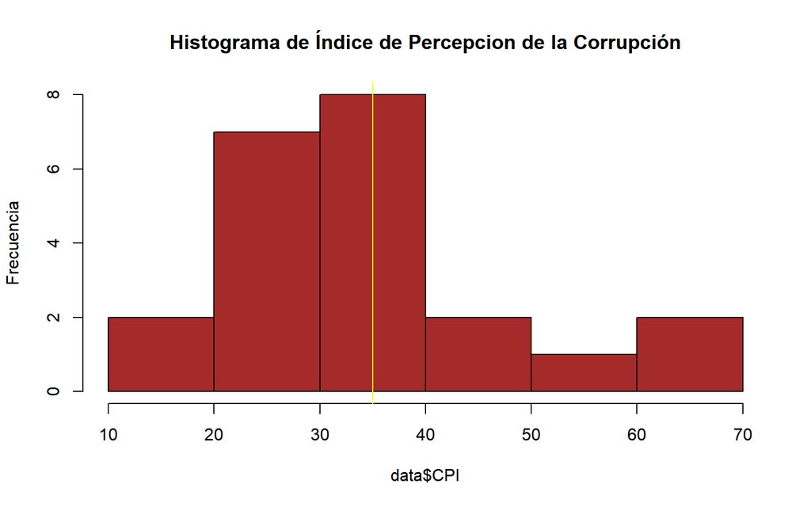

```r
hist(data$CPI, main="Histograma de Índice de Percepcion de la Corrupción", ylab = "Frecuencia", col = "brown")
abline(v=35, col="yellow")
```

```r
skew(data$CPI) #asimetría
```

```
## [1] 1.102629
```

```r
var(data$CPI, na.rm = T) #varianza
```

```
## [1] 177.6558
```

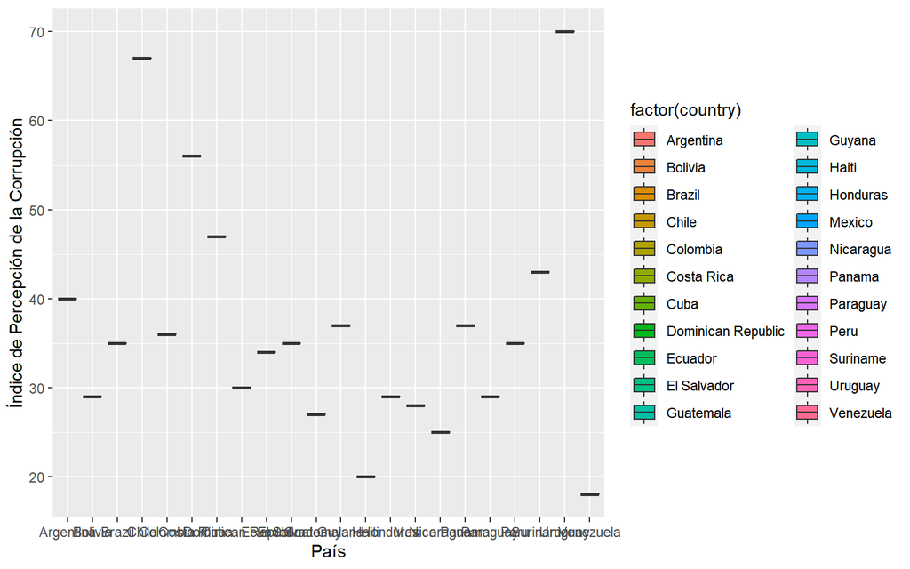

```r
ggplot(data, aes(y = CPI, x = country,fill=factor(country))) +
geom_boxplot() +
xlab("País") +
ylab("Índice de Percepción de la Corrupción")
```

```r
Mode(data$CPI)
```

```
## [1] 29 35
## attr(,"freq")
## [1] 3
```

```r
library(car)
data$CPI_ord = recode(data$CPI, "0:33.3 = 1;33.3:66.7=2 ;66.7:100=3 ")
data$CPI_ord = as.factor(data$CPI_ord)
levels(data$CPI_ord) = c("bajo", "intermedio", "alto")
table(data$CPI_ord)
```

```
##
##       bajo intermedio       alto
##          9         11          2
```

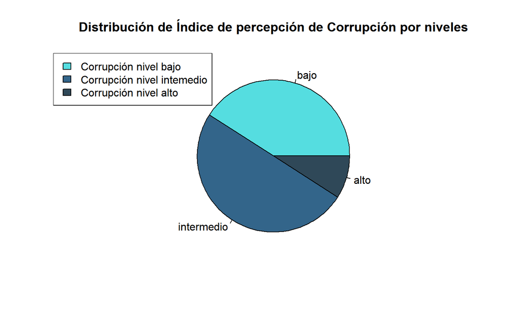

```r
pie(table(data$CPI_ord),col = c("#55DDE0", "#33658A", "#2F4858"), main = "Distribución de Índice de percepción de Corrupción por niveles")
legend("topleft", legend = c("Corrupción nivel bajo", "Corrupción nivel intemedio", "Corrupción nivel alto"), fill =  c("#55DDE0", "#33658A", "#2F4858"))
```

## **Análisis Descriptivo de las variables independientes**

### a) PBI per Cápita

```r
descriptives(data,vars=vars(gdp_pc),freq = TRUE)
```

```
##
##  DESCRIPTIVES
##
##  Descriptives
##  ----------------------------------
##                          gdp_pc
##  ----------------------------------
##    N                           21
##    Missing                      1
##    Mean                  7731.739
##    Median                6718.585
##    Standard deviation    4626.522
##    Minimum               868.3420
##    Maximum               17277.97
##  ----------------------------------
```

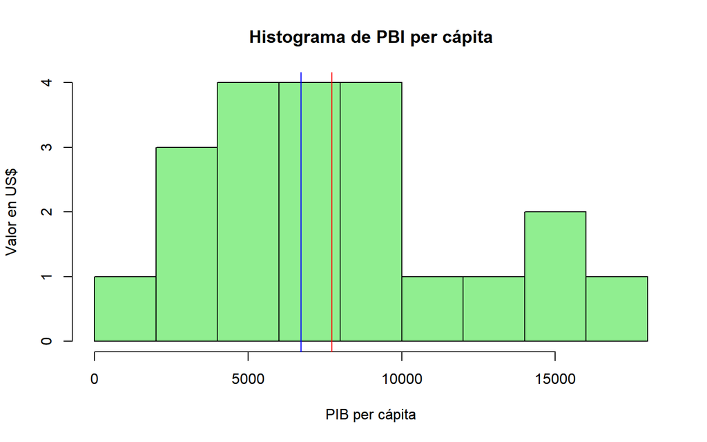

```r
hist(data$gdp_pc, main="Histograma de PBI per cápita", ylab = "Valor en US$", xlab = "PIB per cápita", col = "lightgreen")
abline(v=7731.739, col="red") #media
abline(v=6718.585, col= "blue") #mediana
```

```r
skew(data$gdp_pc) #asimetría
```

```
## [1] 0.5843211
```

```r
var(data$gdp_pc, na.rm = T) #varianza
```

```
## [1] 21404709
```

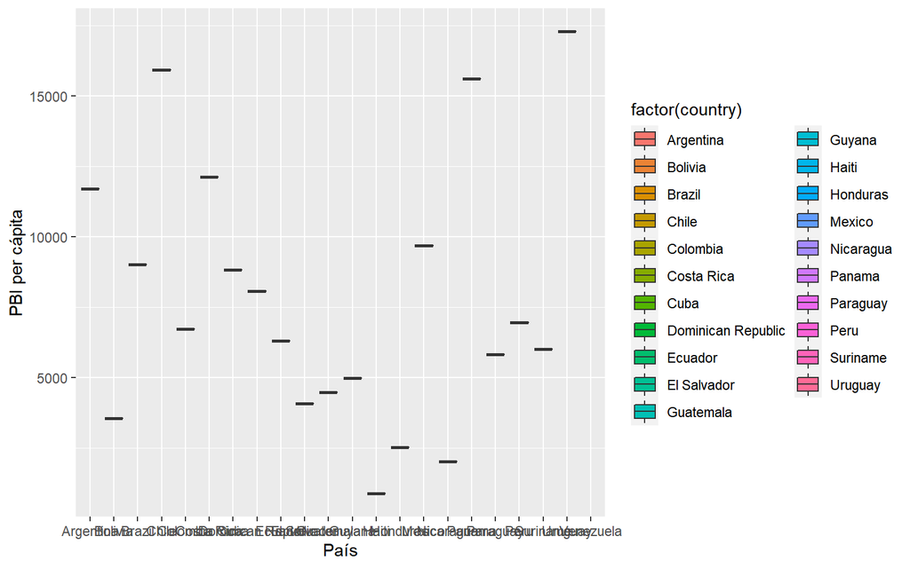

```r
ggplot(data, aes(y = gdp_pc, x = country,fill=factor(country))) +
geom_boxplot() +
xlab("País") +
ylab("PBI per cápita")
```

```r
Mode(data$gdp_pc)
```

```
## [1] NA
## attr(,"freq")
## [1] NA
```

### b) Coeficiente de Gini

```r
str(data$gini)
```

```
##  num [1:22] 39.7 NA 48 NA NA 41.4 NA 49.2 50.4 53.9 ...
```

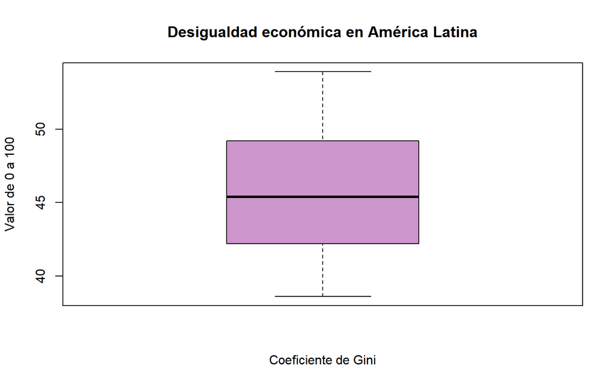

```r
boxplot(data$gini, col=c("plum3"), xlab="Coeficiente de Gini", ylab= "Valor de 0 a 100", legend.text=T, main =  "Desigualdad económica en América Latina")
```

```r
descriptives(data,vars=vars(gini),freq = TRUE)
```

```
##
##  DESCRIPTIVES
##
##  Descriptives
##  ----------------------------------
##                          gini
##  ----------------------------------
##    N                           14
##    Missing                      8
##    Mean                  45.64286
##    Median                45.40000
##    Standard deviation    4.622473
##    Minimum               38.60000
##    Maximum               53.90000
##  ----------------------------------
```

```r
skew(data$gini) #asimetría
```

```
## [1] 0.2107265
```

```r
var(data$gini, na.rm = T) #varianza
```

```
## [1] 21.36725
```

```r
Mode(data$gini)
```

```
## [1] NA
## attr(,"freq")
## [1] NA
```

- El coeficiente de Gini que va de o a 100, donde 0 es una igualdad perfecta y 100 una desigualdad perfecta, permite identificar que tan equitativa es la distribución de la riqueza en los países de la región. La media y la mediana giran entorno a un valor de 45 de coeficiente de gini, lo que nos indicaría que en promedio en la region latinoamericana la desigualdad es intermedia, ni tan alta ni tan baja. El maximo valor de desigualdad es 53.9 y corresponde a Brasil. A partir de ello podemos concluir que existe desigualdad en la región, y ha de ser un tema relevante para las politicas publicas de los gobiernos.

### c) Gasto Público

```r
str(data$govt_spending)
```

```
##  num [1:22] 35 22.4 29.8 NA NA ...
```

```r
descriptives(data,vars=vars(govt_spending),freq = TRUE)
```

```
##
##  DESCRIPTIVES
##
##  Descriptives
##  ---------------------------------------
##                          govt_spending
##  ---------------------------------------
##    N                                13
##    Missing                           9
##    Mean                       22.96208
##    Median                     22.40145
##    Standard deviation         7.445284
##    Minimum                    12.48544
##    Maximum                    36.02540
##  ---------------------------------------
```

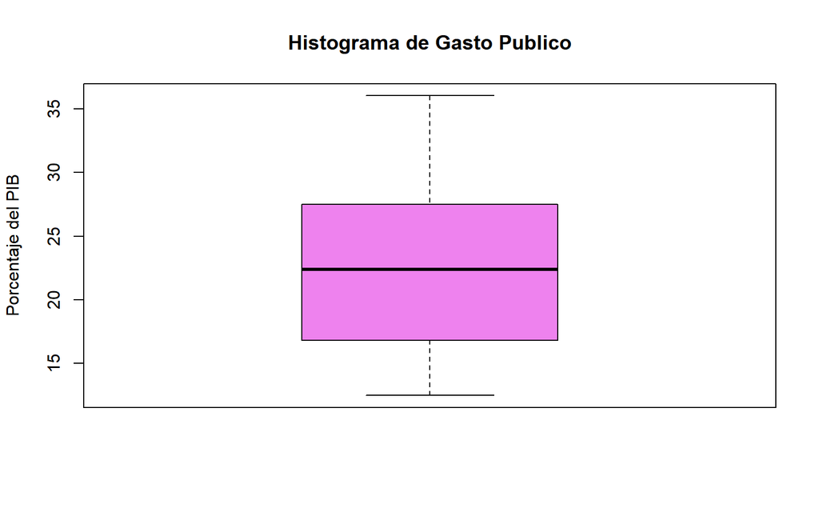

```r
boxplot(data$govt_spending, main="Histograma de Gasto Publico", ylab = "Porcentaje del PIB", col = "violet")
```

- Observamos que en promedio los gobiernos latinoamericanos tienen un gasto público del 22.96208 % con respecto a su Producto Bruto Interno. El valor más alto de Gasto Público es de un 36.02540 % del PIB mientras que el procentaje mínimo de gasto es de 12%. Podríamos decir el que nivel de gasto público en la region latinoamericana no excede el 50% del PIB total.

### d) Tasa de Pobreza

```r
str(data$poverty_rate)
```

```
##  num [1:22] 0.1 NA 1.5 NA NA 1.3 NA 1.7 4.2 4.4 ...
```

```r
descriptives(data,vars=vars(poverty_rate),freq = TRUE)
```

```
##
##  DESCRIPTIVES
##
##  Descriptives
##  --------------------------------------
##                          poverty_rate
##  --------------------------------------
##    N                               14
##    Missing                          8
##    Mean                      3.257143
##    Median                    1.700000
##    Standard deviation        4.175149
##    Minimum                  0.1000000
##    Maximum                   16.90000
##  --------------------------------------
```

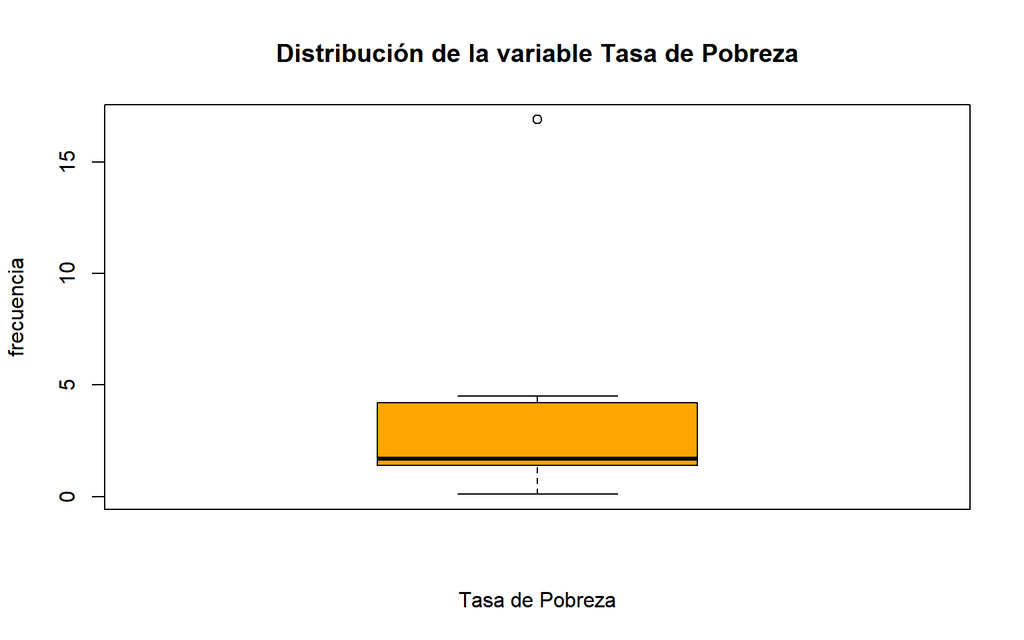

```r
boxplot(data$poverty_rate, col= "orange", main= "Distribución de la variable Tasa de Pobreza", xlab= "Tasa de Pobreza", ylab="frecuencia" )
```

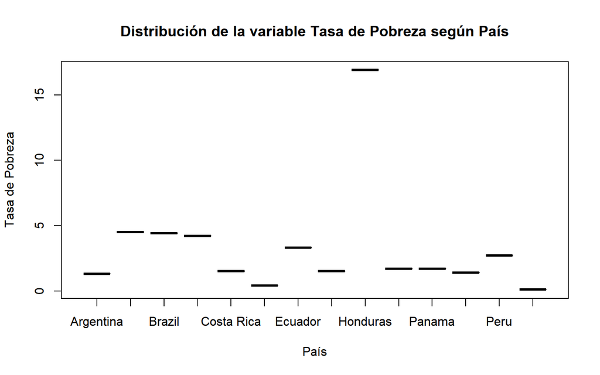

```r
boxplot(data$poverty_rate~ data$country, col= "orange", main= "Distribución de la variable Tasa de Pobreza según País", xlab= "País", ylab="Tasa de Pobreza" )
```

- En promedio, la proporción de personas que viven con menos de $ 1,90 por día en la región es del 3% . Si bien existen países donde menos del 2% de la población vive en pobreza, aproximadamente el 50% de los países, y la mayoría se encuentra por debajo del 5% de tasa de pobreza, existe un país donde el 16% de la población es pobre (Honduras).

### e) Remuneración Burocrática

```r
str(data$bur_rem)
```

```
##  num [1:22] 3.92 3.48 3.46 3.83 3.57 ...
```

```r
data$bur_rem=as.numeric(data$bur_rem)
```

```r
Mode(data$bur_rem)
```

```
## [1] 3.835
## attr(,"freq")
## [1] 2
```

```r
Median(data$bur_rem)
```

```
## [1] 3.761
```

```r
mean(data$bur_rem)
```

```
## [1] 3.721545
```

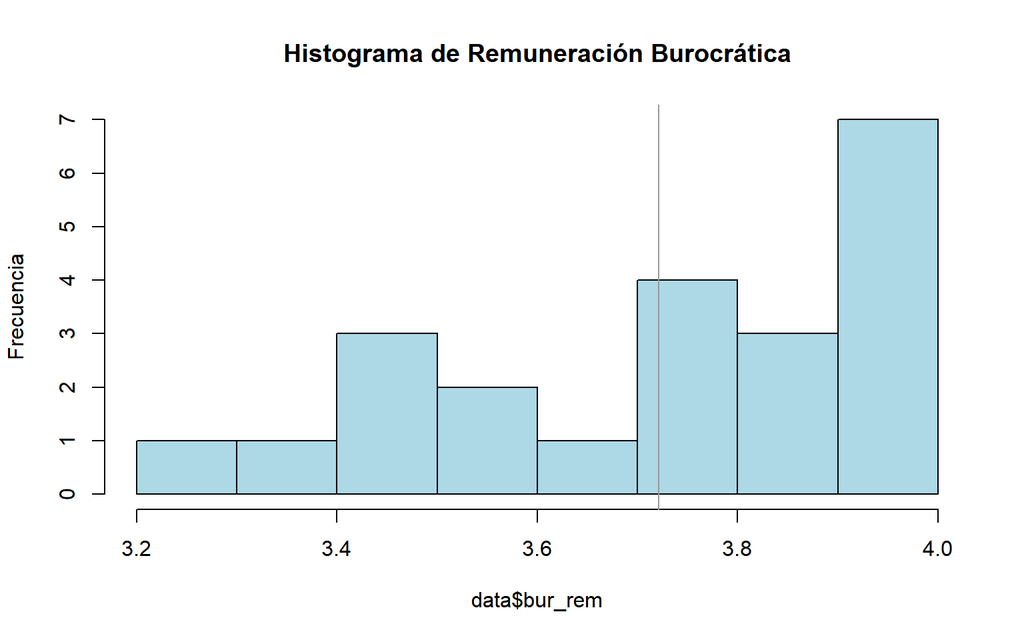

```r
hist(data$bur_rem, main="Histograma de Remuneración Burocrática", ylab = "Frecuencia", col = "lightblue")
abline(v= 3.721545,col='gray60')# media
```

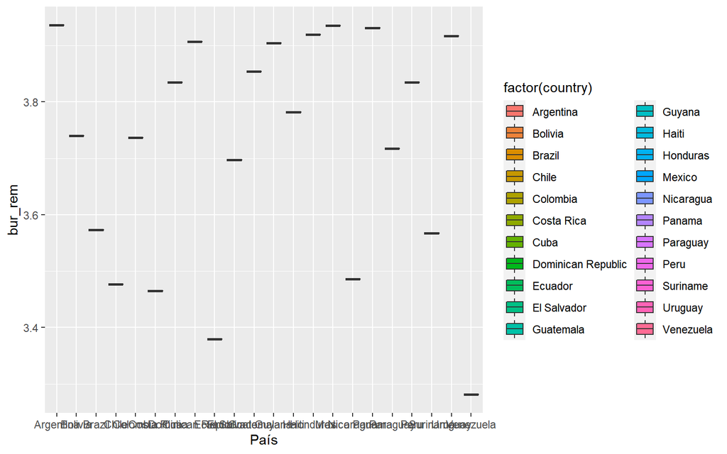

```r
ggplot(data, aes(y = bur_rem, x = country,fill=factor(country))) +
geom_boxplot() +
xlab("País") +
ylab("bur_rem")
```

- La moda de remuneración burocrática es de 3.835.Se mide en una escala de 0 a 4, donde 0 es un país donde no hay burócratas asalariados ni empleados estatales y 4 es un país donde todos o casi todos los burócratas son asalariados y empleados estatales, la media y media es de 3.761 y 3.721545 respectivamente, es decir, que la gran mayoría de países latinoamericanos los burócratas son asalariados y empleados estatales

### f) Financiamiento de campañas públicas

```r
Median(data$pcf)
```

```
## [1] 2.594
```

```r
mean(data$pcf)
```

```
## [1] 2.400227
```

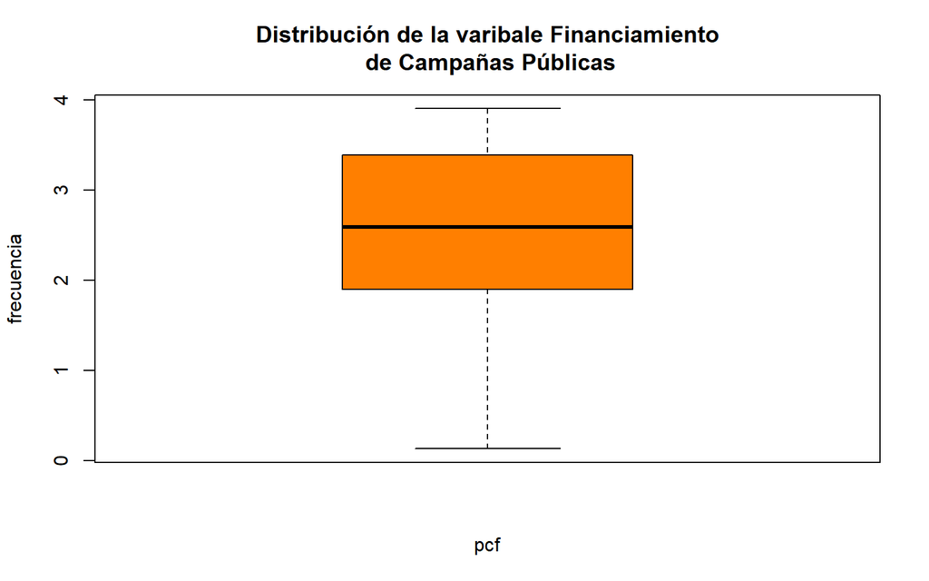

```r
boxplot(data$pcf, col = "darkorange1", main= "Distribución de la varibale Financiamiento\n de Campañas Públicas", xlab= "pcf", ylab="frecuencia")
```

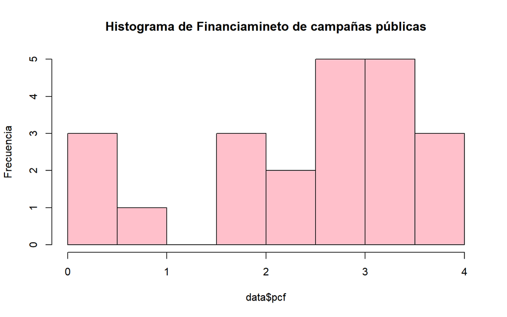

```r
hist(data$pcf, main="Histograma de Financiamineto de campañas públicas", ylab = "Frecuencia", col = "pink")
```

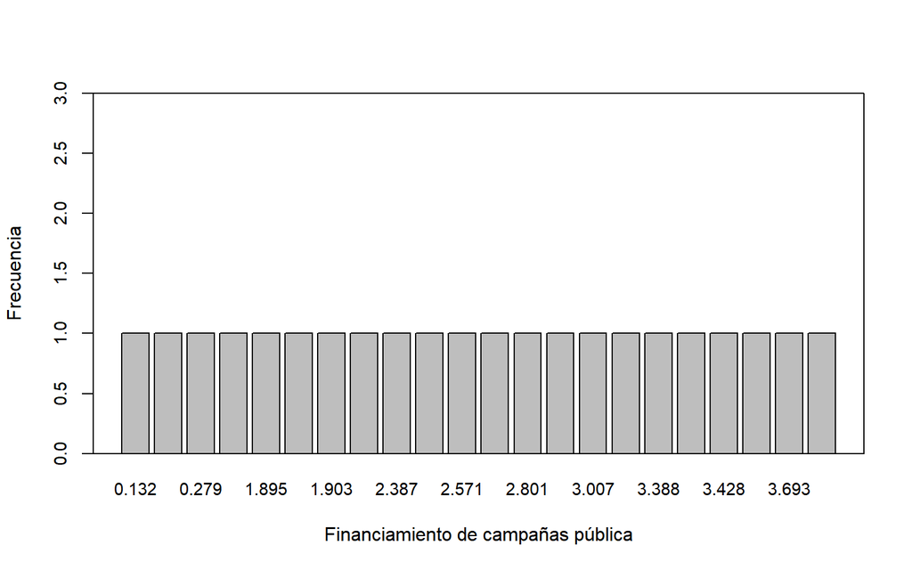

```r
barplot(table(data$pcf),xlab="Financiamiento de campañas pública",ylab="Frecuencia",cex.axis=.9,cex.names=.9,ylim=c(0,3))
abline(h=0,col='gray60')
box()
```

### g) Derechos de propiedad

```r
data$prop_rights=as.numeric(data$prop_rights)
Mode(data$prop_rights)
```

```
## [1] NA
## attr(,"freq")
## [1] 1
```

```r
Median(data$prop_rights)
```

```
## [1] 0.786
```

```r
mean(data$prop_rights)
```

```
## [1] 0.7325455
```

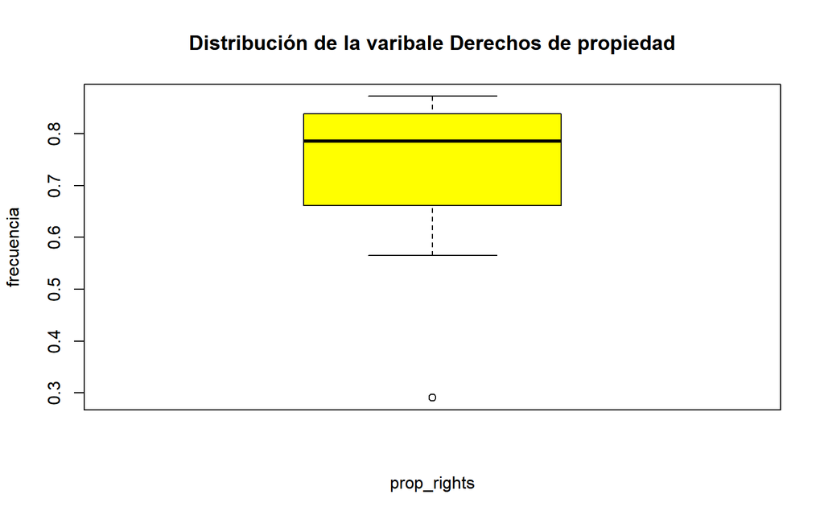

```r
boxplot(data$prop_rights, col = "yellow", main= "Distribución de la varibale Derechos de propiedad", xlab= "prop_rights", ylab="frecuencia")
```

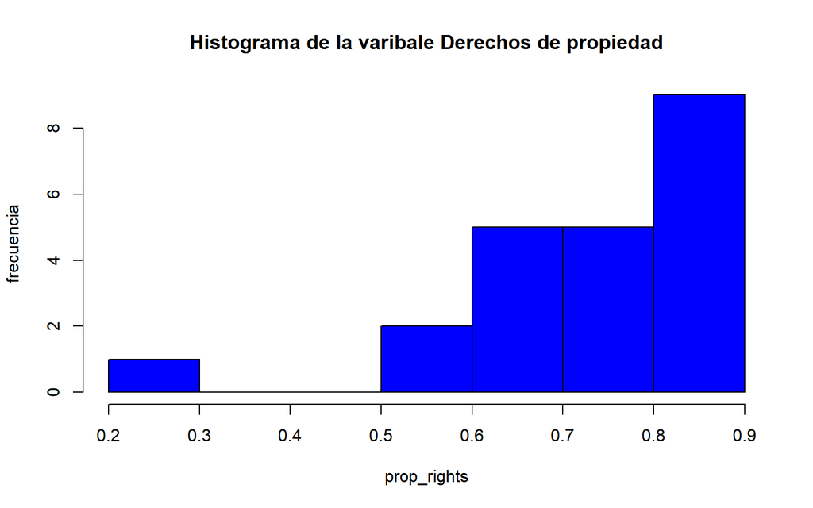

```r
hist(data$prop_rights,col= "blue",main= "Histograma de la varibale Derechos de propiedad", xlab= "prop_rights", ylab="frecuencia")
```

## *¿Qué prueba estadística se realizará?

- Para evaluar la asociación entre la variable de Indice de Percepción de Corrupción (como variable númerica) y el resto de variables independientes desde un análisis bivariado realizaremos pruebas de correlación según la normalidad de distribución de las variables. Asimismo, consideramos que será posible realizar un modelo de regresión logistico ordinal con la variable dependiente ordinal de Índice de Percepción de Corrupción (CPI_ord).

## **Bibliografía**

Diego Bautista, Oscar. (2012). El problema de la corrupción en América Latina y la incorporación de la ética para su solución. Espacios Públicos, 15, 48-62 https://www.redalyc.org/pdf/676/67624803004.pdf

Jong-sung, Y., & Khagram, S. (2005). A Comparative Study of Inequality and Corruption. American Sociological Review, 70(1), 136–157. https://doi.org/10.1177/000312240507000107

Justesen, M. K., & Bjørnskov, C. (2014). EconPapers: Exploiting the Poor: Bureaucratic Corruption and Poverty in Africa. EconPapers. https://econpapers.repec.org/article/eeewdevel/v_3a58_3ay_3a2014_3ai_3ac_3ap_3a106-115.htm

OECD. (2019). La Integridad Pública en América Latina y el Caribe 2018-2019. OCDE: Sociedad Civil. https://www.oecd.org/gov/ethics/integridad-publica-america-latina-caribe-2018-2019.pdf

Ramos Rollón, Marisa y Álvarez García, Francisco Javier. (2019). “El control de la corrupción en América Latina: agenda política, judicialización e internacionalización de la lucha contra la corrupción”. 2019, de Fundación Carolina Sitio web: https://www.fundacioncarolina.es/wp-content/uploads/2019/07/DT_FC_11.p